# Rapport de l’exercice 2 du TP2 de statistique exploratoire : Analyse en Composane Principales

## Question 6 : Projeter dans le premier plan factoriel les lignes actives et les colonnes actives et interpréter

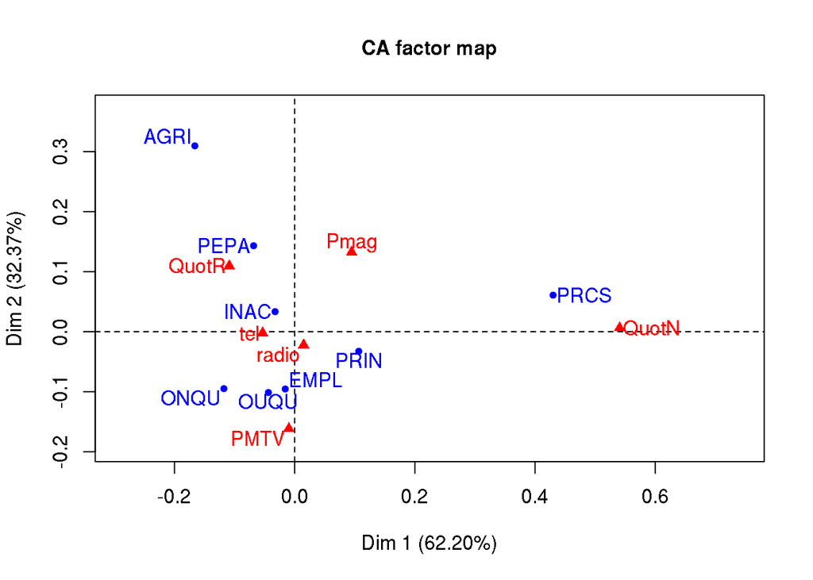

```r
plot.CA(donnees.ca, axes=c(1,2), invisible = "row.sup")
```

Les ouvriers non-qualifiés, les ouvriers qualifiés, les employés sont corrélés. Ils ont plus tendance à consulter la presse magazine T.V., la radio ou le téléphone. Les professions intermédiaires ont un profil qui se rapproche de la qualité d’employé, ils sont corrélés avec la radio. Les inactifs sont plus succeptible d’utiliser le téléphone et la radio. Les professions libérales et les cadres supérieurs sont peu corrélés avec les autres types de profession. Ils sont corrélés avec les quotidiens nationaux. Les petits patrons sont sont bien corrélés avec les quotidiens régionnaux. Les agriculteurs sont quant à eux peu corrélés avec d’autres types de profession et les médias.

## Question 7 : Projeter dans le premier plan factoriel les lignes supplémentaires et interpréter

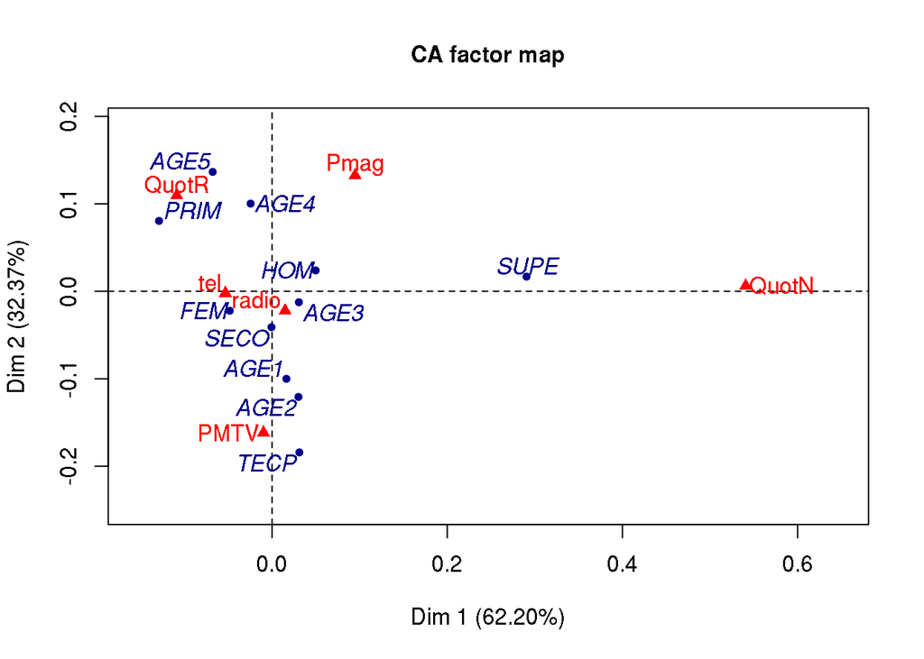

```r
plot.CA(donnees.ca, axes=c(1,2), invisible = c("row"))
```

Le niveau primaire, et les 50 ans et + sont corrélés. Le secondaire, et les 15-49 ans sont corrélés. Le suppérieur est aberrant sur l’axe 1, il n’est pas corrélé avec d’autre type de personne. Le TECP se rapproche des 25-34 ans. Les hommes et femmes sont inversement corrélés sur les 2 axes. Les hommes sont corrélés avec les 35-49 ans tandis que les femmes sont corrélés avec le secondaire. Le supérieur est à mis chemin avec le groupe et les quotidiens nationaux (presque des cadres ?). Le TECP est très corrélé avec la presse magazine T.V.. La radio et le téléphone sont corrélés avec les femmes, les hommes, le secondaire et les 35-49 ans. Les 50-64 ans sont ceux qui se rapproche le plus de la presse magazine. Ils se rapproche aussi des Quotidiens régionnaux avec les 65 ans ou +.